# Standard Normal Distribution

University of Alabama: Class Resources

The rendered version is posted in the [course website](https://mutasim221b.github.io/Mutasim-Personal-Course-2/) (Activities tab). I often experiment with the class activities (and see it in live!) and make updates, but I always post the final version before class starts. To be sure you have the most up-to-date copy, please download it once you’ve settled in before class begins.

# Learning Objectives

By the end of this lesson, you should be able to:

- Describe the key **properties of the standard normal distribution**.
- Interpret a **z-score** as the number of standard deviations an observation is from the mean.
- Compute **probabilities** using the standard normal distribution.
- Transform a normal random variable into a **standard normal variable** using standardization.
- Convert a standard normal value back into the **original measurement scale**.
- Using Z-score to clarify **Significance**…
- **Summary** of Continuous Distributions

# Resources

## Handouts & Activities

- Download Class 12 Handoputs
- Download Normal-Table
- Download Class 12 Excel and Class 12 Excel Solution

## Practice Problems

- Practice problems are essential for your understanding, practice, and exploration. I have posted the practice problems for [Unit 06](https://mutasim221b.github.io/Mutasim-Personal-Course-2/pp.html). Please complete these before attempting the HW.

# Recall…

## The Normal Distribution (Bell Curve)

The **Normal Distribution** (often called the *bell curve*) is one of the most important continuous random variable models.

If $X$ is normally distributed, its support is $(-\infty, \infty)$. The curve is centered at its mean $\mu$, and its spread depends on the standard deviation $\sigma$.

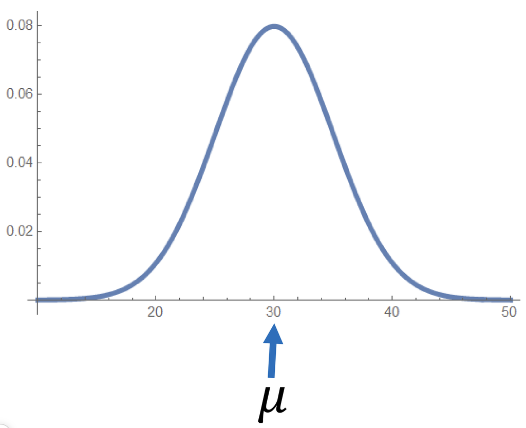

**Math Box: Normal Distribution**

$$\text{If } X \sim N(\mu,\sigma), \text{ then}
\quad
f(x) \;=\; \frac{1}{\sqrt{2\pi}\,\sigma}
\, e^{-\frac{1}{2}\left(\frac{x-\mu}{\sigma}\right)^2},
\qquad -\infty < x < \infty .$$

### Example 1

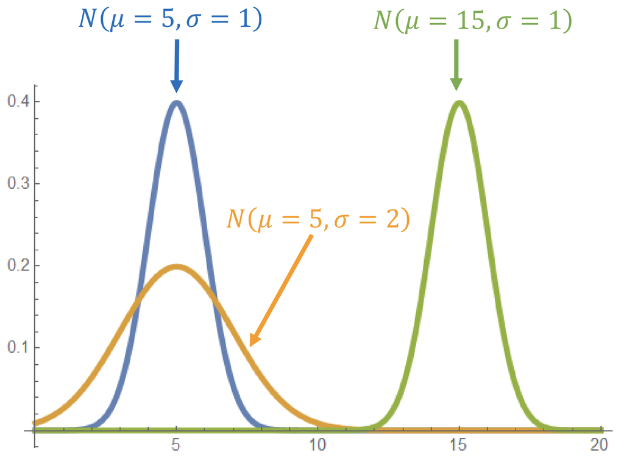

### Example 2: Emperical Rule- Giant!

Suppose heights of adult American men are approximately normally distributed, and you are about to meet a man whose height is $10\sigma$ (10 standard deviations) above the mean. How tall would you expect this person to be? Someone who is “pretty tall” (maybe 6.5 feet), or a giant (the tallest person who has ever lived)?

Assume adult American men’s heights are approximately normal with:

- Mean: $\mu = 70$ inches
- Standard deviation: $\sigma = 4$ inches

A height that is $10\sigma$ above the mean is:

$$\mu + 10\sigma
= 70 + 10(4)
= 110 \text{ inches}.$$

Convert inches to feet/inches:

$$110 \text{ inches} = 9 \text{ ft } 2 \text{ in}.$$

**Interpretation:** A person who is $10\sigma$ above the mean would be about $9'2''$, which is extremely rare. For context, the tallest man who ever lived was about $8'11''$!

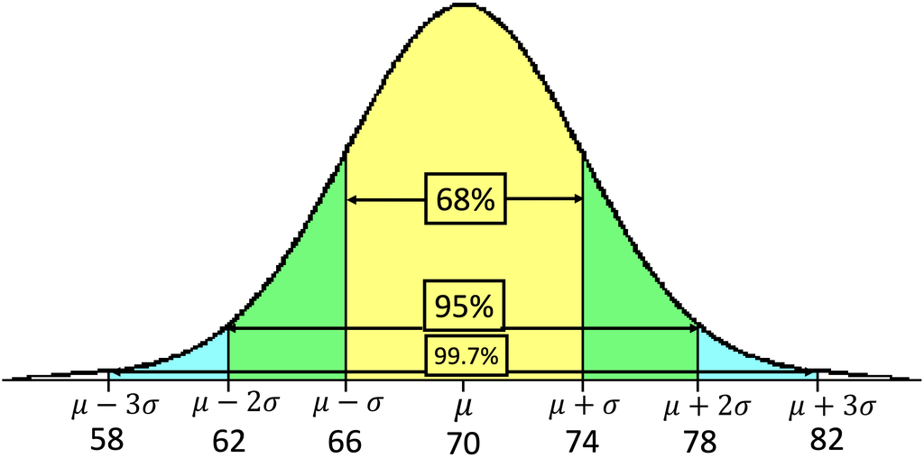

[figure not shown]

# Standard Normal Distribution

There are infinitely many normal curves since any real number is a possible choice for the mean $\mu$ and any positive real number is a choice for the standard deviation $\sigma$. But there is a very special normal curve where $\mu = 0$ and $\sigma = 1$. We call it the **standard normal curve**, and we use $Z$ instead of $X$.

**Math Box: Normal Distribution**

$$Z \sim N(\mu = 0,\ \sigma = 1)$$

$$f(z) = \frac{1}{\sqrt{2\pi}}\,e^{-z^2/2},
\qquad -\infty < z < \infty$$

## “Z-score”

- Tells us how many **standard deviations** a value is away from the mean.
- If a z-score is **positive**, it is larger than the mean.  
  If a z-score is **negative**, it is smaller than the mean.

$$Z = \frac{X - \mu}{\sigma}$$